# Combining and harmonizing datasets

Jose Eduardo Meireles, Anna K. Schweiger, and Jeannine Cavender-Bares

July 2026

A field campaign is rarely one tidy file. It is a folder (or several) of per-scan files, sometimes from more than one instrument, often on different wavelength grids, and usually with several scans per leaf. The goal of this vignette is to turn that mess into a single, analysis-ready `spectra` object: put everything on a common band grid, stack the samples, and collapse replicate scans into per-sample means – without silently mixing things that should not be mixed.

We use a small, real SVC (`.sig`) dataset shipped with the package: seven leaf scans of a single species, *Acer platanoides*, read as **radiance**. The filenames encode the sampling design – a plot (`D2`, `F3`) and a canopy position (`_B_`, `_M_`, `_T_` for bottom, middle, top) – which gives us a clean replicate structure to aggregate over.

```r
acer = read_spectra(system.file("extdata/Acer_example", package = "spectrolab"),
                    type               = "target_radiance",
                    exclude_if_matches = c("BAD", "WR"))

# Turn the filename design into metadata columns we can group by later.
parts = strsplit(names(acer), "_")
meta(acer, "plot")     = sapply(parts, `[`, 2)
meta(acer, "position") = sapply(parts, `[`, 4)

acer
```

```
#> spectra object
#> number of samples: 7
#> bands: 340.5 to 2522.8 (1024 bands, **overlap not matched**)
#> metadata (2): plot, position
#> instrument: svc
#>
#>                        340.5  342    343.4  344.9  346.3  347.8  349.3  ...
#> ACPL_D2_P1_B_1_001.sig 0.8106 0.9909 1.3439 1.3573 0.9093 0.8528 0.8053
#> ACPL_D2_P1_B_2_001.sig 0.8106 1.101  1.5506 1.5512 1.3639 1.0233 0.6442
#> ACPL_D2_P1_M_1_000.sig 0.9264 1.1744 1.1027 1.0341 0.8486 0.9096 1.0737
#> ACPL_D2_P1_M_2_000.sig 1.2738 1.2111 0.7236 0.6787 0.7274 0.8528 0.6442
#> ACPL_D2_P1_T_1_000.sig 1.0422 1.2111 1.0338 1.1634 1.273  1.0233 1.0468
```

## The problem

Two things get in the way of simply stacking a campaign together: the band grids differ, and the *quantities* differ. Reading two more datasets that ship with the package makes the point. The Acer scans are SVC radiance on a 1024-band grid; a second SVC dataset is **reflectance**; a PSR (`.sed`) dataset is raw **digital numbers** on a 2151-band grid.

```r
serbin = read_spectra(system.file("extdata/svc_raw_and_overlap_matched_serbin/SVC_Files",
                                   package = "spectrolab"),
                      format = "sig")                        # SVC reflectance

psr    = read_spectra(system.file("extdata/psr_DN_brett", package = "spectrolab"),
                      format = "sed", type = "target_radiance")   # PSR digital numbers

# Same campaign spirit, three different band grids:
data.frame(
    dataset  = c("acer (radiance)", "serbin (reflectance)", "psr (DN)"),
    n_bands  = c(length(bands(acer)), length(bands(serbin)), length(bands(psr))),
    min_band = c(min(bands(acer)),    min(bands(serbin)),    min(bands(psr))),
    max_band = c(max(bands(acer)),    max(bands(serbin)),    max(bands(psr)))
)
```

```
#>                dataset n_bands min_band max_band
#> 1      acer (radiance)    1024    340.5   2522.8
#> 2 serbin (reflectance)    1024    338.2   2517.2
#> 3             psr (DN)    2151    350.0   2500.0
```

The grids disagree in length (1024 vs. 2151) and, even where the lengths match, in the actual wavelengths sampled. `combine()` refuses to guess: it stacks two `spectra` only when their band labels are identical – checked by both length **and** `all.equal()`. That guard is exactly why harmonization comes first. (The quantity mismatch – radiance vs. reflectance vs. DN – is a second, deeper problem that no amount of resampling fixes; see An honest caveat.)

From here on we work entirely within the Acer radiance dataset, one species and one quantity, so every operation is legitimate.

## Put everything on a common grid

Raw SVC data carries three overlapping detectors, so its bands are not strictly increasing. `resample()` (like `normalize()`) requires strictly increasing bands, so we first resolve the detector overlap with `match_sensors()` – see the dedicated *Matching sensor overlap* vignette for what that step does and how to control it.

```r
acm = match_sensors(acer, splice_at = guess_splice_at(acer))
```

Now resample onto a target grid. `resample()` is not linear interpolation: it models each output band as a Gaussian over the input bands, and `make_fwhm()` picks a sensible full-width-half-maximum for each new band from the original spacing. The key idea for harmonization is that **every dataset is resampled to the same `new_bands`** – that shared target is what makes them combinable.

```r
new_bands = seq(400, 2400, by = 5)                       # one common target grid
acer_rs   = resample(acm, new_bands = new_bands, fwhm = make_fwhm(acm, new_bands))

acer_rs
```

```
#> spectra object
#> number of samples: 7
#> bands: 400 to 2400 (401 bands)
#> metadata (2): plot, position
#>
#>                        400              405              410
#> ACPL_D2_P1_B_1_001.sig 1.81522316132325 1.83290741499835 2.10763101621177
#> ACPL_D2_P1_B_2_001.sig 1.81544177176599 1.94340356801983 2.17361892865414
#> ACPL_D2_P1_M_1_000.sig 1.73299328021081 1.93331846637421 2.11847690291555
#> ACPL_D2_P1_M_2_000.sig 1.79186302782917 2.04980952850374 2.34321307808195
#> ACPL_D2_P1_T_1_000.sig 1.7981526820772  2.016114073333   2.13844755163101
#>                        415              420              425
#> ACPL_D2_P1_B_1_001.sig 2.29355838894116 2.50408092965092 2.67813230144781
#> ACPL_D2_P1_B_2_001.sig 2.36584044326027 2.56980331703782 2.89066890546798
#> ACPL_D2_P1_M_1_000.sig 2.27824086358331 2.59270728243514 2.78151630465058
#> ACPL_D2_P1_M_2_000.sig 2.45584930216759 2.78234463985325 3.08634950337213
#> ACPL_D2_P1_T_1_000.sig 2.29541805938216 2.6076623623664  2.8468507882146
#>                        430              ...
#> ACPL_D2_P1_B_1_001.sig 2.94370786925132
#> ACPL_D2_P1_B_2_001.sig 3.13555108766821
#> ACPL_D2_P1_M_1_000.sig 3.05005950287384
#> ACPL_D2_P1_M_2_000.sig 3.36701231367519
#> ACPL_D2_P1_T_1_000.sig 3.11852690620127
```

## Combine

`combine()` stacks the samples of two `spectra` that share a band grid. If they do not, it stops rather than producing a corrupt object – the guard from the problem section, seen here directly:

```r
# acm is on the native (997-band) grid; acer_rs is on the 5-nm grid.
combine(acm, acer_rs)
```

```
#> Error in `combine.spectra()`:
#> ! Spectra must have the same bands. Consider using `resample()` first
```

Once the grids agree, combining is trivial. Pretend the two plots were collected as separate batches (different days, different folders); we split them, then stack them back together. Metadata columns are carried through and merged by name, so the reassembled object is identical to the original.

```r
batch_d2 = acer_rs[meta(acer_rs)$plot == "D2", ]
batch_f3 = acer_rs[meta(acer_rs)$plot == "F3", ]

campaign = combine(batch_d2, batch_f3)
campaign
```

```
#> spectra object
#> number of samples: 7
#> bands: 400 to 2400 (401 bands)
#> metadata (2): plot, position
#>
#>                        400              405              410
#> ACPL_D2_P1_B_1_001.sig 1.81522316132325 1.83290741499835 2.10763101621177
#> ACPL_D2_P1_B_2_001.sig 1.81544177176599 1.94340356801983 2.17361892865414
#> ACPL_D2_P1_M_1_000.sig 1.73299328021081 1.93331846637421 2.11847690291555
#> ACPL_D2_P1_M_2_000.sig 1.79186302782917 2.04980952850374 2.34321307808195
#> ACPL_D2_P1_T_1_000.sig 1.7981526820772  2.016114073333   2.13844755163101
#>                        415              420              425
#> ACPL_D2_P1_B_1_001.sig 2.29355838894116 2.50408092965092 2.67813230144781
#> ACPL_D2_P1_B_2_001.sig 2.36584044326027 2.56980331703782 2.89066890546798
#> ACPL_D2_P1_M_1_000.sig 2.27824086358331 2.59270728243514 2.78151630465058
#> ACPL_D2_P1_M_2_000.sig 2.45584930216759 2.78234463985325 3.08634950337213
#> ACPL_D2_P1_T_1_000.sig 2.29541805938216 2.6076623623664  2.8468507882146
#>                        430              ...
#> ACPL_D2_P1_B_1_001.sig 2.94370786925132
#> ACPL_D2_P1_B_2_001.sig 3.13555108766821
#> ACPL_D2_P1_M_1_000.sig 3.05005950287384
#> ACPL_D2_P1_M_2_000.sig 3.36701231367519
#> ACPL_D2_P1_T_1_000.sig 3.11852690620127
```

```r
# c() and rbind() are the idiomatic shorthands -- both just repeatedly
# apply combine(), so they preserve the spectra class and merge metadata.
identical(dim(c(batch_d2, batch_f3)), dim(campaign))
```

```
#> [1] TRUE
```

For more than two objects, `Reduce(combine, list(...))` (or `c()` / `rbind()` with all of them) folds the whole list into one.

## Aggregate replicate scans

The campaign still holds replicate scans – two per canopy position within plot D2, plus one bottom scan from F3. `aggregate()` collapses those replicates into per-group means. Grouping by canopy position turns seven scans into three per-position mean spectra.

The subtlety is metadata. Averaging a numeric column is obvious, but text columns (like `plot`) have no mean. Wrapping the metadata function in `try_keep_txt()` tells `aggregate()` to fall back to the unique text values instead of erroring or producing `NA` – so the bottom-position mean correctly records that it came from plots `D2, F3`.

```r
agg = aggregate(acer_rs,
                by       = meta(acer_rs)$position,
                FUN      = mean,
                FUN_meta = try_keep_txt(mean))

agg
```

```
#> spectra object
#> number of samples: 3
#> bands: 400 to 2400 (401 bands)
#> metadata (2): plot, position
#>
#>   400              405              410              415
#> B 1.72036255015226 1.82531365755881 2.04601216723375 2.26199894159864
#> M 1.76242815401999 1.99156399743897 2.23084499049875 2.36704508287545
#> T 1.86073773049927 2.12494273010713 2.25568062730231 2.45156397123639
#>   420              425              430              ...
#> B 2.45444932134316 2.69178940839243 2.94783244039027
#> M 2.6875259611442  2.93393290401135 3.20853590827451
#> T 2.769096754232   3.03253606516085 3.34227733854174
```

```r
meta(agg)
```

```
#>     plot position
#> 1 D2, F3        B
#> 2     D2        M
#> 3     D2        T
```

`split()` is the inverse operation: `split(acer_rs, meta(acer_rs)$position)` returns a list of one `spectra` per group, which is handy when you want to process groups independently before recombining them.

## An honest caveat

`spectrolab` deliberately does **not** track a `quantity` attribute on a `spectra` object. Nothing in `combine()` or `aggregate()` will stop you from stacking radiance on top of reflectance, or reflectance on top of digital numbers – the band-grid guard checks wavelengths, not physical units. That responsibility is yours.

The worked example above is safe because it lives entirely inside one dataset: Acer radiance, one species, one instrument. The three datasets from *The problem* are **not** mutually combinable – `acer` is radiance, `serbin` is reflectance, `psr` is digital numbers – and no resampling changes that. Merging across instruments is an advanced case that requires matching the quantity (convert to a common physical unit first) **and** the grid (resample to shared `new_bands`) before `combine()` is meaningful.

## Before and after

The payoff: ragged per-scan inputs on the left, one harmonized object on the right – per-position mean spectra with 95% quantile ribbons, colored by canopy position.

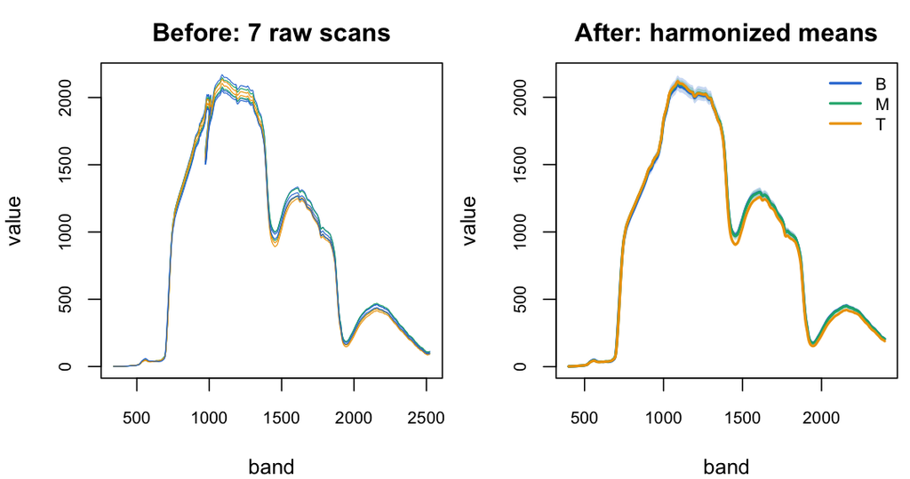

```r
gp = group_palette(acer_rs, by = "position")   # named colors, by position level

op = par(mfrow = c(1, 2), mar = c(4, 4, 2.5, 0.5))

## Before: raw scans, overlapping detectors, colored by position
plot(acer, col = species_cols(acer, by = "position"), lwd = 0.7,
     cex.axis = 0.8, main = "Before: 7 raw scans")

## After: harmonized per-position means with quantile ribbons
plot(acer_rs, type = "n", cex.axis = 0.8, main = "After: harmonized means")
for(p in names(gp$pal)){
    sp = acer_rs[meta(acer_rs)$position == p, ]
    plot_quantile(sp, col = adjustcolor(gp$pal[[p]], 0.25),
                  border = FALSE, add = TRUE)
}
plot(agg, col = gp$pal[names(agg)], lwd = 2, add = TRUE)
legend("topright", legend = names(gp$pal), col = gp$pal,
       lwd = 2, bty = "n", cex = 0.8)
```

```r
par(op)
```

From a folder of overlapping-detector scans on a vendor grid to a single object on a clean 5-nm grid, with replicate scans averaged and their design metadata intact – ready for analysis.